# Complete Guide to ModalitiesDiceClusterer

Hierarchical Clustering of Categorical Variable Modalities

M2RClust Team

2025-12-02

## Introduction

The `ModalitiesDiceClusterer` implements **hierarchical clustering of categorical variable modalities** (factor levels) rather than clustering observations or variables. This approach, inspired by `HClustVar`, is particularly useful for:

- Understanding relationships between categories across multiple variables
- Discovering patterns in categorical data structure
- Creating synthetic variables by grouping related modalities
- Exploratory analysis of survey data, customer segments, product categories

### Key Features

- **Automatic discretization**: Handles mixed data (numeric + categorical)
- **Flexible dissimilarity**: Dice coefficient (default) or Cramér’s V
- **MCA projection**: Visualize modalities in low-dimensional space
- **Illustrative variables**: Project supplementary variables onto existing clusters
- **Rich diagnostics**: Silhouette analysis, elbow plots, inertia decomposition

### Algorithm Principle

1. **Disjunctive coding**: Each modality becomes a binary indicator column
2. **Dissimilarity computation**: Pairwise distances between all modalities
3. **Hierarchical clustering**: Apply `hclust()` with chosen linkage
4. **Tree cutting**: Partition modalities into K groups
5. **MCA analysis**: Project onto factorial space for visualization

## Installation and Loading

```r
library(M2RClust)

# Check if required packages are available
if (!requireNamespace("FactoMineR", quietly = TRUE)) {
  stop("Package 'FactoMineR' is required for this vignette. Please install it with: install.packages('FactoMineR')")
}
```

## Example Data

### Pure Categorical Data

```r
# Create sample categorical data
set.seed(42)
n <- 150

survey_data <- data.frame(
  Age = factor(sample(c("18-25", "26-35", "36-45", "46+"), n, replace = TRUE)),
  Income = factor(sample(c("Low", "Medium", "High"), n, replace = TRUE)),
  Education = factor(sample(c("HS", "Bachelor", "Master", "PhD"), n, replace = TRUE)),
  Region = factor(sample(c("North", "South", "East", "West"), n, replace = TRUE)),
  Preference = factor(sample(c("A", "B", "C"), n, replace = TRUE))
)

cat("Survey data dimensions:", dim(survey_data), "\n")
```

```
#> Survey data dimensions: 150 5
```

```r
str(survey_data)
```

```
#> 'data.frame':    150 obs. of  5 variables:
#>  $ Age       : Factor w/ 4 levels "18-25","26-35",..: 1 1 1 1 2 4 2 2 1 4 ...
#>  $ Income    : Factor w/ 3 levels "High","Low","Medium": 3 2 1 2 2 2 1 1 2 3 ...
#>  $ Education : Factor w/ 4 levels "Bachelor","HS",..: 2 3 1 2 1 4 1 1 2 3 ...
#>  $ Region    : Factor w/ 4 levels "East","North",..: 4 1 3 4 2 3 3 1 1 2 ...
#>  $ Preference: Factor w/ 3 levels "A","B","C": 1 1 3 2 3 2 2 1 1 2 ...
```

### Mixed Data (Numeric + Categorical)

```r
# Mixed dataset with automatic discretization
set.seed(123)
n <- 200

mixed_data <- data.frame(
  # Numeric variables (will be discretized)
  Score = rnorm(n, mean = 75, sd = 15),
  Age = runif(n, 18, 65),
  Salary = rlnorm(n, meanlog = 10.5, sdlog = 0.5),

  # Categorical variables
  Gender = factor(sample(c("M", "F"), n, replace = TRUE)),
  Department = factor(sample(c("Sales", "IT", "HR", "Marketing"), n, replace = TRUE)),
  Level = factor(sample(c("Junior", "Mid", "Senior"), n, replace = TRUE))
)

cat("Mixed data dimensions:", dim(mixed_data), "\n")
```

```
#> Mixed data dimensions: 200 6
```

```r
str(mixed_data)
```

```
#> 'data.frame':    200 obs. of  6 variables:
#>  $ Score     : num  66.6 71.5 98.4 76.1 76.9 ...
#>  $ Age       : num  64.3 24.4 60.5 45.1 36.6 ...
#>  $ Salary    : num  25397 24926 22714 21456 29185 ...
#>  $ Gender    : Factor w/ 2 levels "F","M": 2 1 1 2 1 2 2 1 1 2 ...
#>  $ Department: Factor w/ 4 levels "HR","IT","Marketing",..: 4 3 2 4 4 4 3 4 4 4 ...
#>  $ Level     : Factor w/ 3 levels "Junior","Mid",..: 2 1 2 3 1 1 1 1 1 1 ...
```

## Basic Usage

### Creating and Fitting

```r
# Create the clusterer for categorical data
clusterer <- ModalitiesDiceClusterer$new(
  n_groups = 4,
  linkage = "ward.D2",
  dissimilarity = "dice"
)

# Fit the model
clusterer$fit(survey_data)

# Display results
clusterer$print()
```

```
#> ModalitiesDiceClusterer
#> Fitted with 4 modality-groups
#>
#> 1 2 3 4
#> 3 9 4 2
```

### Cluster Assignments

```r
# Get modality-cluster assignments
cluster_table <- clusterer$get_cluster_table()
print(cluster_table)
```

```
#>              Modality Cluster Frequency
#> 1          Income.Low       1        51
#> 2           Age.18-25       1        45
#> 3         Region.East       1        42
#> 4        Preference.C       2        51
#> 5  Education.Bachelor       2        48
#> 6         Income.High       2        44
#> 7           Age.26-35       2        43
#> 8        Region.South       2        42
#> 9        Education.HS       2        37
#> 10        Region.West       2        30
#> 11      Education.PhD       2        28
#> 12          Age.36-45       2        24
#> 13       Preference.A       3        46
#> 14            Age.46+       3        38
#> 15   Education.Master       3        37
#> 16       Region.North       3        36
#> 17      Income.Medium       4        55
#> 18       Preference.B       4        53
```

### Detailed Summary

```r
# Comprehensive summary with inertia decomposition
summary_results <- clusterer$summary()
```

```
#> ================================================================================
#>                     MODALITIES DICE CLUSTERER SUMMARY
#> ================================================================================
#>
#> --- MODEL CONFIGURATION ---
#> Dissimilarity measure: DICE
#> Linkage method: ward.D2
#> Number of clusters: 4
#> Auto-discretization: Yes (n_bins=4)
#>
#> --- DATA INFORMATION ---
#> Number of observations: 150
#> Number of variables: 5
#> Number of modalities: 18
#> Modalities: Age.18-25, Age.26-35, Age.36-45, Age.46+, Income.High, Income.Low, Income.Medium, Education.Bachelor, Education.HS, Education.Master, Education.PhD, Region.East, Region.North, Region.South, Region.West, Preference.A, Preference.B, Preference.C
#>
#> --- CLUSTER ASSIGNMENTS ---
#> Cluster sizes (n_modalities): 3, 9, 4, 2
#>
#> Detailed cluster composition:
#>
#> Cluster 1 (3 modalities, total freq: 138):
#>   - Income.Low (freq: 51, 34.0%)
#>   - Age.18-25 (freq: 45, 30.0%)
#>   - Region.East (freq: 42, 28.0%)
#>
#> Cluster 2 (9 modalities, total freq: 347):
#>   - Preference.C (freq: 51, 34.0%)
#>   - Education.Bachelor (freq: 48, 32.0%)
#>   - Income.High (freq: 44, 29.3%)
#>   - Age.26-35 (freq: 43, 28.7%)
#>   - Region.South (freq: 42, 28.0%)
#>   - Education.HS (freq: 37, 24.7%)
#>   - Region.West (freq: 30, 20.0%)
#>   - Education.PhD (freq: 28, 18.7%)
#>   - Age.36-45 (freq: 24, 16.0%)
#>
#> Cluster 3 (4 modalities, total freq: 157):
#>   - Preference.A (freq: 46, 30.7%)
#>   - Age.46+ (freq: 38, 25.3%)
```

[output cut: 29 more lines]

```
#>  7. Age.18-25 (cluster 1): 32.6471 (5.69%)
#>  8. Income.High (cluster 2): 32.4118 (5.65%)
#>  9. Age.26-35 (cluster 2): 32.1765 (5.61%)
#> 10. Region.East (cluster 1): 31.9412 (5.57%)
#>
#> --- DISTANCE MATRIX STATISTICS ---
#> Distance range: [4.5826, 7.2801]
#> Mean distance: 5.6248
#> Median distance: 5.5678
#>
#> --- HIERARCHICAL CLUSTERING DETAILS ---
#> Height range: [4.5826, 7.0548]
#> Number of merges: 17
#>
#> ================================================================================
```

## Dissimilarity Measures

### Dice Coefficient (Default)

The Dice dissimilarity measures how differently two modalities are distributed across observations:

$$d_{Dice}^2(i,j) = \frac{1}{2}\sum_k
(x_{ki} - x_{kj})^2$$

```r
clusterer_dice <- ModalitiesDiceClusterer$new(
  n_groups = 3,
  dissimilarity = "dice"
)
clusterer_dice$fit(survey_data)

summary_dice <- clusterer_dice$summary()
```

```
#> ================================================================================
#>                     MODALITIES DICE CLUSTERER SUMMARY
#> ================================================================================
#>
#> --- MODEL CONFIGURATION ---
#> Dissimilarity measure: DICE
#> Linkage method: ward.D2
#> Number of clusters: 3
#> Auto-discretization: Yes (n_bins=4)
#>
#> --- DATA INFORMATION ---
#> Number of observations: 150
#> Number of variables: 5
#> Number of modalities: 18
#> Modalities: Age.18-25, Age.26-35, Age.36-45, Age.46+, Income.High, Income.Low, Income.Medium, Education.Bachelor, Education.HS, Education.Master, Education.PhD, Region.East, Region.North, Region.South, Region.West, Preference.A, Preference.B, Preference.C
#>
#> --- CLUSTER ASSIGNMENTS ---
#> Cluster sizes (n_modalities): 7, 9, 2
#>
#> Detailed cluster composition:
#>
#> Cluster 1 (7 modalities, total freq: 295):
#>   - Income.Low (freq: 51, 34.0%)
#>   - Preference.A (freq: 46, 30.7%)
#>   - Age.18-25 (freq: 45, 30.0%)
#>   - Region.East (freq: 42, 28.0%)
#>   - Age.46+ (freq: 38, 25.3%)
#>   - Education.Master (freq: 37, 24.7%)
#>   - Region.North (freq: 36, 24.0%)
#>
#> Cluster 2 (9 modalities, total freq: 347):
#>   - Preference.C (freq: 51, 34.0%)
#>   - Education.Bachelor (freq: 48, 32.0%)
#>   - Income.High (freq: 44, 29.3%)
#>   - Age.26-35 (freq: 43, 28.7%)
#>   - Region.South (freq: 42, 28.0%)
#>   - Education.HS (freq: 37, 24.7%)
#>   - Region.West (freq: 30, 20.0%)
#>   - Education.PhD (freq: 28, 18.7%)
#>   - Age.36-45 (freq: 24, 16.0%)
```

[output cut: 26 more lines]

```
#>  7. Age.18-25 (cluster 1): 32.6471 (5.69%)
#>  8. Income.High (cluster 2): 32.4118 (5.65%)
#>  9. Age.26-35 (cluster 2): 32.1765 (5.61%)
#> 10. Region.East (cluster 1): 31.9412 (5.57%)
#>
#> --- DISTANCE MATRIX STATISTICS ---
#> Distance range: [4.5826, 7.2801]
#> Mean distance: 5.6248
#> Median distance: 5.5678
#>
#> --- HIERARCHICAL CLUSTERING DETAILS ---
#> Height range: [4.5826, 7.0548]
#> Number of merges: 17
#>
#> ================================================================================
```

```r
var_exp_dice <- summary_dice$variance_explained
if (!is.null(var_exp_dice) && is.numeric(var_exp_dice)) {
  cat("Homogeneity (Dice):", round(var_exp_dice, 4), "\n")
} else {
  cat("Homogeneity (Dice): Unable to compute\n")
}
```

```
#> Homogeneity (Dice): Unable to compute
```

### Cramér’s V

Cramér’s V measures association strength between categorical variables, transformed to dissimilarity:

$$d_{Cramer}^2(i,j) = 1 -
V^2(i,j)$$

```r
clusterer_cramer <- ModalitiesDiceClusterer$new(
  n_groups = 3,
  dissimilarity = "cramer"
)
clusterer_cramer$fit(survey_data)

summary_cramer <- clusterer_cramer$summary()
```

```
#> ================================================================================
#>                     MODALITIES DICE CLUSTERER SUMMARY
#> ================================================================================
#>
#> --- MODEL CONFIGURATION ---
#> Dissimilarity measure: CRAMER
#> Linkage method: ward.D2
#> Number of clusters: 3
#> Auto-discretization: Yes (n_bins=4)
#>
#> --- DATA INFORMATION ---
#> Number of observations: 150
#> Number of variables: 5
#> Number of modalities: 18
#> Modalities: Age.18-25, Age.26-35, Age.36-45, Age.46+, Income.High, Income.Low, Income.Medium, Education.Bachelor, Education.HS, Education.Master, Education.PhD, Region.East, Region.North, Region.South, Region.West, Preference.A, Preference.B, Preference.C
#>
#> --- CLUSTER ASSIGNMENTS ---
#> Cluster sizes (n_modalities): 8, 3, 7
#>
#> Detailed cluster composition:
#>
#> Cluster 1 (8 modalities, total freq: 300):
#>   - Age.18-25 (freq: 45, 30.0%)
#>   - Age.26-35 (freq: 43, 28.7%)
#>   - Region.East (freq: 42, 28.0%)
#>   - Region.South (freq: 42, 28.0%)
#>   - Age.46+ (freq: 38, 25.3%)
#>   - Region.North (freq: 36, 24.0%)
#>   - Region.West (freq: 30, 20.0%)
#>   - Age.36-45 (freq: 24, 16.0%)
#>
#> Cluster 2 (3 modalities, total freq: 150):
#>   - Income.Medium (freq: 55, 36.7%)
#>   - Income.Low (freq: 51, 34.0%)
#>   - Income.High (freq: 44, 29.3%)
#>
#> Cluster 3 (7 modalities, total freq: 300):
#>   - Preference.B (freq: 53, 35.3%)
#>   - Preference.C (freq: 51, 34.0%)
#>   - Education.Bachelor (freq: 48, 32.0%)
```

[output cut: 26 more lines]

```
#>  7. Age.36-45 (cluster 1): 0.8188 (5.65%)
#>  8. Income.Medium (cluster 2): 0.8136 (5.61%)
#>  9. Age.46+ (cluster 1): 0.8064 (5.56%)
#> 10. Age.18-25 (cluster 1): 0.7968 (5.49%)
#>
#> --- DISTANCE MATRIX STATISTICS ---
#> Distance range: [0.4539, 0.9987]
#> Mean distance: 0.8887
#> Median distance: 0.9435
#>
#> --- HIERARCHICAL CLUSTERING DETAILS ---
#> Height range: [0.4539, 1.5646]
#> Number of merges: 17
#>
#> ================================================================================
```

```r
var_exp_cramer <- summary_cramer$variance_explained
if (!is.null(var_exp_cramer) && is.numeric(var_exp_cramer)) {
  cat("Homogeneity (Cramér):", round(var_exp_cramer, 4), "\n")
} else {
  cat("Homogeneity (Cramér): Unable to compute\n")
}
```

```
#> Homogeneity (Cramér): Unable to compute
```

### Comparing Measures

```r
# Extract dissimilarity matrices
dice_mat <- clusterer_dice$get_dice_matrix(as_dist = FALSE)
cramer_mat <- clusterer_cramer$measure_dissimilarity(as_dist = FALSE)

cat("Dice distance range: [",
    round(min(dice_mat), 3), ", ",
    round(max(dice_mat), 3), "]\n", sep = "")
```

```
#> Dice distance range: [0, 7.28]
```

```r
cat("Cramér distance range: [",
    round(min(cramer_mat), 3), ", ",
    round(max(cramer_mat), 3), "]\n", sep = "")
```

```
#> Cramér distance range: [0, 0.999]
```

## Linkage Methods

### Ward’s Method (Default)

Ward’s linkage minimizes within-cluster variance - best for compact, spherical clusters:

```r
clust_ward <- ModalitiesDiceClusterer$new(
  n_groups = 4,
  linkage = "ward.D2"
)
clust_ward$fit(survey_data)
summary_ward <- clust_ward$summary()
```

```
#> ================================================================================
#>                     MODALITIES DICE CLUSTERER SUMMARY
#> ================================================================================
#>
#> --- MODEL CONFIGURATION ---
#> Dissimilarity measure: DICE
#> Linkage method: ward.D2
#> Number of clusters: 4
#> Auto-discretization: Yes (n_bins=4)
#>
#> --- DATA INFORMATION ---
#> Number of observations: 150
#> Number of variables: 5
#> Number of modalities: 18
#> Modalities: Age.18-25, Age.26-35, Age.36-45, Age.46+, Income.High, Income.Low, Income.Medium, Education.Bachelor, Education.HS, Education.Master, Education.PhD, Region.East, Region.North, Region.South, Region.West, Preference.A, Preference.B, Preference.C
#>
#> --- CLUSTER ASSIGNMENTS ---
#> Cluster sizes (n_modalities): 3, 9, 4, 2
#>
#> Detailed cluster composition:
#>
#> Cluster 1 (3 modalities, total freq: 138):
#>   - Income.Low (freq: 51, 34.0%)
#>   - Age.18-25 (freq: 45, 30.0%)
#>   - Region.East (freq: 42, 28.0%)
#>
#> Cluster 2 (9 modalities, total freq: 347):
#>   - Preference.C (freq: 51, 34.0%)
#>   - Education.Bachelor (freq: 48, 32.0%)
#>   - Income.High (freq: 44, 29.3%)
#>   - Age.26-35 (freq: 43, 28.7%)
#>   - Region.South (freq: 42, 28.0%)
#>   - Education.HS (freq: 37, 24.7%)
#>   - Region.West (freq: 30, 20.0%)
#>   - Education.PhD (freq: 28, 18.7%)
#>   - Age.36-45 (freq: 24, 16.0%)
#>
#> Cluster 3 (4 modalities, total freq: 157):
#>   - Preference.A (freq: 46, 30.7%)
#>   - Age.46+ (freq: 38, 25.3%)
```

[output cut: 29 more lines]

```
#>  7. Age.18-25 (cluster 1): 32.6471 (5.69%)
#>  8. Income.High (cluster 2): 32.4118 (5.65%)
#>  9. Age.26-35 (cluster 2): 32.1765 (5.61%)
#> 10. Region.East (cluster 1): 31.9412 (5.57%)
#>
#> --- DISTANCE MATRIX STATISTICS ---
#> Distance range: [4.5826, 7.2801]
#> Mean distance: 5.6248
#> Median distance: 5.5678
#>
#> --- HIERARCHICAL CLUSTERING DETAILS ---
#> Height range: [4.5826, 7.0548]
#> Number of merges: 17
#>
#> ================================================================================
```

```r
var_exp_ward <- summary_ward$variance_explained
if (!is.null(var_exp_ward) && is.numeric(var_exp_ward)) {
  cat("Variance explained (Ward):", round(var_exp_ward, 4), "\n")
}
```

### Complete Linkage

Complete linkage maximizes between-cluster distance - creates well-separated clusters:

```r
clust_complete <- ModalitiesDiceClusterer$new(
  n_groups = 4,
  linkage = "complete"
)
clust_complete$fit(survey_data)
summary_complete <- clust_complete$summary()
```

```
#> ================================================================================
#>                     MODALITIES DICE CLUSTERER SUMMARY
#> ================================================================================
#>
#> --- MODEL CONFIGURATION ---
#> Dissimilarity measure: DICE
#> Linkage method: complete
#> Number of clusters: 4
#> Auto-discretization: Yes (n_bins=4)
#>
#> --- DATA INFORMATION ---
#> Number of observations: 150
#> Number of variables: 5
#> Number of modalities: 18
#> Modalities: Age.18-25, Age.26-35, Age.36-45, Age.46+, Income.High, Income.Low, Income.Medium, Education.Bachelor, Education.HS, Education.Master, Education.PhD, Region.East, Region.North, Region.South, Region.West, Preference.A, Preference.B, Preference.C
#>
#> --- CLUSTER ASSIGNMENTS ---
#> Cluster sizes (n_modalities): 3, 7, 4, 4
#>
#> Detailed cluster composition:
#>
#> Cluster 1 (3 modalities, total freq: 138):
#>   - Income.Low (freq: 51, 34.0%)
#>   - Age.18-25 (freq: 45, 30.0%)
#>   - Region.East (freq: 42, 28.0%)
#>
#> Cluster 2 (7 modalities, total freq: 280):
#>   - Preference.C (freq: 51, 34.0%)
#>   - Education.Bachelor (freq: 48, 32.0%)
#>   - Income.High (freq: 44, 29.3%)
#>   - Age.26-35 (freq: 43, 28.7%)
#>   - Region.South (freq: 42, 28.0%)
#>   - Education.PhD (freq: 28, 18.7%)
#>   - Age.36-45 (freq: 24, 16.0%)
#>
#> Cluster 3 (4 modalities, total freq: 157):
#>   - Preference.A (freq: 46, 30.7%)
#>   - Age.46+ (freq: 38, 25.3%)
#>   - Education.Master (freq: 37, 24.7%)
#>   - Region.North (freq: 36, 24.0%)
```

[output cut: 29 more lines]

```
#>  7. Age.18-25 (cluster 1): 32.6471 (5.69%)
#>  8. Income.High (cluster 2): 32.4118 (5.65%)
#>  9. Age.26-35 (cluster 2): 32.1765 (5.61%)
#> 10. Region.East (cluster 1): 31.9412 (5.57%)
#>
#> --- DISTANCE MATRIX STATISTICS ---
#> Distance range: [4.5826, 7.2801]
#> Mean distance: 5.6248
#> Median distance: 5.5678
#>
#> --- HIERARCHICAL CLUSTERING DETAILS ---
#> Height range: [4.5826, 7.2801]
#> Number of merges: 17
#>
#> ================================================================================
```

```r
var_exp_complete <- summary_complete$variance_explained
if (!is.null(var_exp_complete) && is.numeric(var_exp_complete)) {
  cat("Variance explained (Complete):", round(var_exp_complete, 4), "\n")
}
```

### Average Linkage

Average linkage balances within and between-cluster distances:

```r
clust_average <- ModalitiesDiceClusterer$new(
  n_groups = 4,
  linkage = "average"
)
clust_average$fit(survey_data)
summary_average <- clust_average$summary()
```

```
#> ================================================================================
#>                     MODALITIES DICE CLUSTERER SUMMARY
#> ================================================================================
#>
#> --- MODEL CONFIGURATION ---
#> Dissimilarity measure: DICE
#> Linkage method: average
#> Number of clusters: 4
#> Auto-discretization: Yes (n_bins=4)
#>
#> --- DATA INFORMATION ---
#> Number of observations: 150
#> Number of variables: 5
#> Number of modalities: 18
#> Modalities: Age.18-25, Age.26-35, Age.36-45, Age.46+, Income.High, Income.Low, Income.Medium, Education.Bachelor, Education.HS, Education.Master, Education.PhD, Region.East, Region.North, Region.South, Region.West, Preference.A, Preference.B, Preference.C
#>
#> --- CLUSTER ASSIGNMENTS ---
#> Cluster sizes (n_modalities): 3, 11, 2, 2
#>
#> Detailed cluster composition:
#>
#> Cluster 1 (3 modalities, total freq: 138):
#>   - Income.Low (freq: 51, 34.0%)
#>   - Age.18-25 (freq: 45, 30.0%)
#>   - Region.East (freq: 42, 28.0%)
#>
#> Cluster 2 (11 modalities, total freq: 405):
#>   - Preference.A (freq: 46, 30.7%)
#>   - Income.High (freq: 44, 29.3%)
#>   - Age.26-35 (freq: 43, 28.7%)
#>   - Region.South (freq: 42, 28.0%)
#>   - Age.46+ (freq: 38, 25.3%)
#>   - Education.HS (freq: 37, 24.7%)
#>   - Education.Master (freq: 37, 24.7%)
#>   - Region.North (freq: 36, 24.0%)
#>   - Region.West (freq: 30, 20.0%)
#>   - Education.PhD (freq: 28, 18.7%)
#>   - Age.36-45 (freq: 24, 16.0%)
#>
#> Cluster 3 (2 modalities, total freq: 108):
```

[output cut: 29 more lines]

```
#>  7. Age.18-25 (cluster 1): 32.6471 (5.69%)
#>  8. Income.High (cluster 2): 32.4118 (5.65%)
#>  9. Age.26-35 (cluster 2): 32.1765 (5.61%)
#> 10. Region.East (cluster 1): 31.9412 (5.57%)
#>
#> --- DISTANCE MATRIX STATISTICS ---
#> Distance range: [4.5826, 7.2801]
#> Mean distance: 5.6248
#> Median distance: 5.5678
#>
#> --- HIERARCHICAL CLUSTERING DETAILS ---
#> Height range: [4.5826, 5.8985]
#> Number of merges: 17
#>
#> ================================================================================
```

```r
var_exp_average <- summary_average$variance_explained
if (!is.null(var_exp_average) && is.numeric(var_exp_average)) {
  cat("Variance explained (Average):", round(var_exp_average, 4), "\n")
}
```

## Automatic Discretization

For mixed data (numeric + categorical), automatic discretization converts numeric variables into categorical bins using quantiles:

```r
# Enable automatic discretization (default)
clusterer_auto <- ModalitiesDiceClusterer$new(
  n_groups = 5,
  auto_discretize = TRUE,
  n_bins = 4  # Quartiles
)

clusterer_auto$fit(mixed_data)
clusterer_auto$print()
```

```
#> ModalitiesDiceClusterer
#> Fitted with 5 modality-groups
#>
#> 1 2 3 4 5
#> 4 6 7 3 1
```

```r
# Check discretized data
cat("\nOriginal variables:\n")
```

```
#>
#> Original variables:
```

```r
print(names(mixed_data))
```

```
#> [1] "Score"      "Age"        "Salary"     "Gender"     "Department"
#> [6] "Level"
```

```r
cat("\nModalities after discretization:\n")
```

```
#>
#> Modalities after discretization:
```

```r
print(clusterer_auto$get_modalities())
```

```
#>  [1] "Score.Q1"             "Score.Q2"             "Score.Q3"
#>  [4] "Score.Q4"             "Age.Q1"               "Age.Q2"
#>  [7] "Age.Q3"               "Age.Q4"               "Salary.Q1"
#> [10] "Salary.Q2"            "Salary.Q3"            "Salary.Q4"
#> [13] "Gender.F"             "Gender.M"             "Department.HR"
#> [16] "Department.IT"        "Department.Marketing" "Department.Sales"
#> [19] "Level.Junior"         "Level.Mid"            "Level.Senior"
```

### Controlling Bin Count

```r
# Fewer bins (terciles)
clust_3bins <- ModalitiesDiceClusterer$new(
  n_groups = 4,
  auto_discretize = TRUE,
  n_bins = 3
)
clust_3bins$fit(mixed_data)

# More bins (quintiles)
clust_5bins <- ModalitiesDiceClusterer$new(
  n_groups = 4,
  auto_discretize = TRUE,
  n_bins = 5
)
clust_5bins$fit(mixed_data)

cat("3 bins - modalities count:", length(clust_3bins$get_modalities()), "\n")
```

```
#> 3 bins - modalities count: 18
```

```r
cat("5 bins - modalities count:", length(clust_5bins$get_modalities()), "\n")
```

```
#> 5 bins - modalities count: 24
```

## Visualizations

### Dendrogram

The dendrogram shows the hierarchical structure of modality merging:

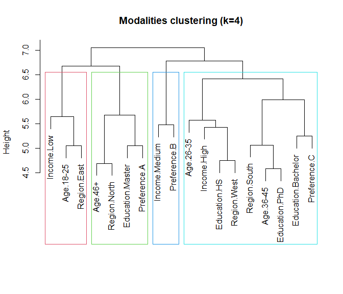

Hierarchical clustering dendrogram

```r
clusterer$plot_dendrogram()
```

### MCA Projection

Multiple Correspondence Analysis (MCA) projects modalities into 2D space:

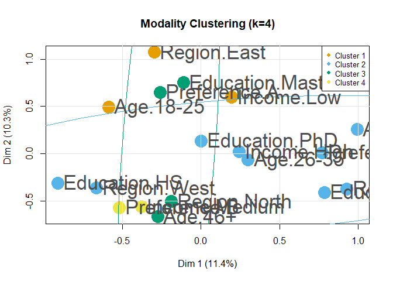

MCA projection of modalities colored by cluster

```r
clusterer$plot_mca(
  color_by_cluster = TRUE,
  add_ellipses = TRUE,
  show_labels = TRUE
)
```

### MCA without Cluster Colors

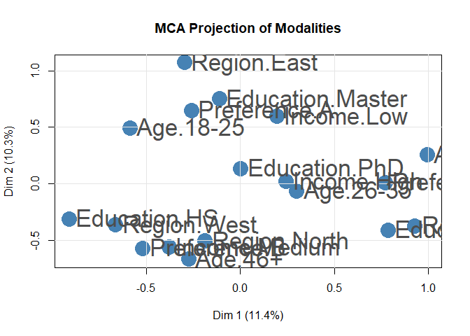

MCA projection without clustering

```r
clusterer$plot_mca(
  color_by_cluster = FALSE,
  show_labels = TRUE
)
```

### Silhouette Analysis

Evaluate clustering quality - higher silhouette = better separation:

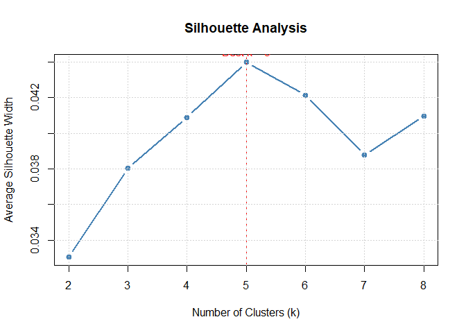

Silhouette scores across different K values

```r
clusterer$plot_silhouette(min_k = 2, max_k = 8)
```

### Elbow Plot

Find optimal K using within-cluster inertia:

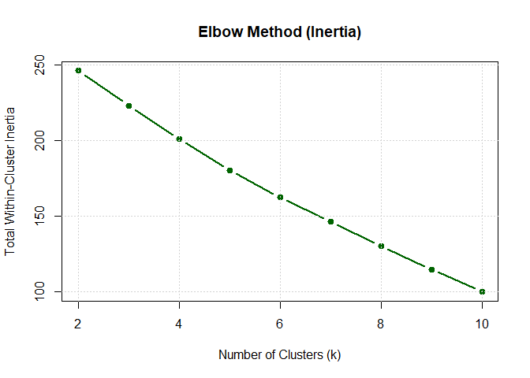

Elbow method for optimal K

```r
clusterer$plot_elbow(min_k = 2, max_k = 10)
```

## Re-cutting the Tree

```r
# Original clustering
cat("Original K =", clusterer$n_groups, "\n")
```

```
#> Original K = 4
```

```r
print(table(clusterer$groups))
```

```
#>
#> 1 2 3 4
#> 3 9 4 2
```

```r
# Try K = 3
clusterer_k3 <- ModalitiesDiceClusterer$new(n_groups = 3)
clusterer_k3$fit(survey_data)
cat("\nWith K = 3:\n")
```

```
#>
#> With K = 3:
```

```r
print(table(clusterer_k3$groups))
```

```
#>
#> 1 2 3
#> 7 9 2
```

```r
# Try K = 6
clusterer_k6 <- ModalitiesDiceClusterer$new(n_groups = 6)
clusterer_k6$fit(survey_data)
cat("\nWith K = 6:\n")
```

```
#>
#> With K = 6:
```

```r
print(table(clusterer_k6$groups))
```

```
#>
#> 1 2 3 4 5 6
#> 3 4 3 4 2 2
```

```r
# Compare variance explained
summary_k3 <- clusterer_k3$summary()
```

```
#> ================================================================================
#>                     MODALITIES DICE CLUSTERER SUMMARY
#> ================================================================================
#>
#> --- MODEL CONFIGURATION ---
#> Dissimilarity measure: DICE
#> Linkage method: ward.D2
#> Number of clusters: 3
#> Auto-discretization: Yes (n_bins=4)
#>
#> --- DATA INFORMATION ---
#> Number of observations: 150
#> Number of variables: 5
#> Number of modalities: 18
#> Modalities: Age.18-25, Age.26-35, Age.36-45, Age.46+, Income.High, Income.Low, Income.Medium, Education.Bachelor, Education.HS, Education.Master, Education.PhD, Region.East, Region.North, Region.South, Region.West, Preference.A, Preference.B, Preference.C
#>
#> --- CLUSTER ASSIGNMENTS ---
#> Cluster sizes (n_modalities): 7, 9, 2
#>
#> Detailed cluster composition:
#>
#> Cluster 1 (7 modalities, total freq: 295):
#>   - Income.Low (freq: 51, 34.0%)
#>   - Preference.A (freq: 46, 30.7%)
#>   - Age.18-25 (freq: 45, 30.0%)
#>   - Region.East (freq: 42, 28.0%)
#>   - Age.46+ (freq: 38, 25.3%)
#>   - Education.Master (freq: 37, 24.7%)
#>   - Region.North (freq: 36, 24.0%)
#>
#> Cluster 2 (9 modalities, total freq: 347):
#>   - Preference.C (freq: 51, 34.0%)
#>   - Education.Bachelor (freq: 48, 32.0%)
#>   - Income.High (freq: 44, 29.3%)
#>   - Age.26-35 (freq: 43, 28.7%)
#>   - Region.South (freq: 42, 28.0%)
#>   - Education.HS (freq: 37, 24.7%)
#>   - Region.West (freq: 30, 20.0%)
#>   - Education.PhD (freq: 28, 18.7%)
#>   - Age.36-45 (freq: 24, 16.0%)
```

[output cut: 26 more lines]

```
#>  7. Age.18-25 (cluster 1): 32.6471 (5.69%)
#>  8. Income.High (cluster 2): 32.4118 (5.65%)
#>  9. Age.26-35 (cluster 2): 32.1765 (5.61%)
#> 10. Region.East (cluster 1): 31.9412 (5.57%)
#>
#> --- DISTANCE MATRIX STATISTICS ---
#> Distance range: [4.5826, 7.2801]
#> Mean distance: 5.6248
#> Median distance: 5.5678
#>
#> --- HIERARCHICAL CLUSTERING DETAILS ---
#> Height range: [4.5826, 7.0548]
#> Number of merges: 17
#>
#> ================================================================================
```

```r
summary_k4 <- clusterer$summary()
```

```
#> ================================================================================
#>                     MODALITIES DICE CLUSTERER SUMMARY
#> ================================================================================
#>
#> --- MODEL CONFIGURATION ---
#> Dissimilarity measure: DICE
#> Linkage method: ward.D2
#> Number of clusters: 4
#> Auto-discretization: Yes (n_bins=4)
#>
#> --- DATA INFORMATION ---
#> Number of observations: 150
#> Number of variables: 5
#> Number of modalities: 18
#> Modalities: Age.18-25, Age.26-35, Age.36-45, Age.46+, Income.High, Income.Low, Income.Medium, Education.Bachelor, Education.HS, Education.Master, Education.PhD, Region.East, Region.North, Region.South, Region.West, Preference.A, Preference.B, Preference.C
#>
#> --- CLUSTER ASSIGNMENTS ---
#> Cluster sizes (n_modalities): 3, 9, 4, 2
#>
#> Detailed cluster composition:
#>
#> Cluster 1 (3 modalities, total freq: 138):
#>   - Income.Low (freq: 51, 34.0%)
#>   - Age.18-25 (freq: 45, 30.0%)
#>   - Region.East (freq: 42, 28.0%)
#>
#> Cluster 2 (9 modalities, total freq: 347):
#>   - Preference.C (freq: 51, 34.0%)
#>   - Education.Bachelor (freq: 48, 32.0%)
#>   - Income.High (freq: 44, 29.3%)
#>   - Age.26-35 (freq: 43, 28.7%)
#>   - Region.South (freq: 42, 28.0%)
#>   - Education.HS (freq: 37, 24.7%)
#>   - Region.West (freq: 30, 20.0%)
#>   - Education.PhD (freq: 28, 18.7%)
#>   - Age.36-45 (freq: 24, 16.0%)
#>
#> Cluster 3 (4 modalities, total freq: 157):
#>   - Preference.A (freq: 46, 30.7%)
#>   - Age.46+ (freq: 38, 25.3%)
```

[output cut: 29 more lines]

```
#>  7. Age.18-25 (cluster 1): 32.6471 (5.69%)
#>  8. Income.High (cluster 2): 32.4118 (5.65%)
#>  9. Age.26-35 (cluster 2): 32.1765 (5.61%)
#> 10. Region.East (cluster 1): 31.9412 (5.57%)
#>
#> --- DISTANCE MATRIX STATISTICS ---
#> Distance range: [4.5826, 7.2801]
#> Mean distance: 5.6248
#> Median distance: 5.5678
#>
#> --- HIERARCHICAL CLUSTERING DETAILS ---
#> Height range: [4.5826, 7.0548]
#> Number of merges: 17
#>
#> ================================================================================
```

```r
summary_k6 <- clusterer_k6$summary()
```

```
#> ================================================================================
#>                     MODALITIES DICE CLUSTERER SUMMARY
#> ================================================================================
#>
#> --- MODEL CONFIGURATION ---
#> Dissimilarity measure: DICE
#> Linkage method: ward.D2
#> Number of clusters: 6
#> Auto-discretization: Yes (n_bins=4)
#>
#> --- DATA INFORMATION ---
#> Number of observations: 150
#> Number of variables: 5
#> Number of modalities: 18
#> Modalities: Age.18-25, Age.26-35, Age.36-45, Age.46+, Income.High, Income.Low, Income.Medium, Education.Bachelor, Education.HS, Education.Master, Education.PhD, Region.East, Region.North, Region.South, Region.West, Preference.A, Preference.B, Preference.C
#>
#> --- CLUSTER ASSIGNMENTS ---
#> Cluster sizes (n_modalities): 3, 4, 3, 4, 2, 2
#>
#> Detailed cluster composition:
#>
#> Cluster 1 (3 modalities, total freq: 138):
#>   - Income.Low (freq: 51, 34.0%)
#>   - Age.18-25 (freq: 45, 30.0%)
#>   - Region.East (freq: 42, 28.0%)
#>
#> Cluster 2 (4 modalities, total freq: 154):
#>   - Income.High (freq: 44, 29.3%)
#>   - Age.26-35 (freq: 43, 28.7%)
#>   - Education.HS (freq: 37, 24.7%)
#>   - Region.West (freq: 30, 20.0%)
#>
#> Cluster 3 (3 modalities, total freq: 94):
#>   - Region.South (freq: 42, 28.0%)
#>   - Education.PhD (freq: 28, 18.7%)
#>   - Age.36-45 (freq: 24, 16.0%)
#>
#> Cluster 4 (4 modalities, total freq: 157):
#>   - Preference.A (freq: 46, 30.7%)
#>   - Age.46+ (freq: 38, 25.3%)
```

[output cut: 35 more lines]

```
#>  7. Age.18-25 (cluster 1): 32.6471 (5.69%)
#>  8. Income.High (cluster 2): 32.4118 (5.65%)
#>  9. Age.26-35 (cluster 2): 32.1765 (5.61%)
#> 10. Region.East (cluster 1): 31.9412 (5.57%)
#>
#> --- DISTANCE MATRIX STATISTICS ---
#> Distance range: [4.5826, 7.2801]
#> Mean distance: 5.6248
#> Median distance: 5.5678
#>
#> --- HIERARCHICAL CLUSTERING DETAILS ---
#> Height range: [4.5826, 7.0548]
#> Number of merges: 17
#>
#> ================================================================================
```

```r
if (!is.null(summary_k3$variance_explained) && is.numeric(summary_k3$variance_explained)) {
  cat("\nVariance explained (K=3):", round(summary_k3$variance_explained, 4), "\n")
}
if (!is.null(summary_k4$variance_explained) && is.numeric(summary_k4$variance_explained)) {
  cat("Variance explained (K=4):", round(summary_k4$variance_explained, 4), "\n")
}
if (!is.null(summary_k6$variance_explained) && is.numeric(summary_k6$variance_explained)) {
  cat("Variance explained (K=6):", round(summary_k6$variance_explained, 4), "\n")
}
```

## Illustrative Variables

Project supplementary (illustrative) variables onto the existing clustering structure:

```r
# Re-fit clusterer with K=4 for illustrative example
clusterer_illus <- ModalitiesDiceClusterer$new(n_groups = 4)
clusterer_illus$fit(survey_data)

# Create illustrative variable
set.seed(999)
illustrative_var <- factor(
  sample(c("Type1", "Type2", "Type3"), nrow(survey_data), replace = TRUE)
)

# Project onto existing clusters
prediction <- clusterer_illus$predict_illustrative(illustrative_var)

cat("=== Illustrative Variable Projection ===\n\n")
```

```
#> === Illustrative Variable Projection ===
```

```r
cat("Distances to active modalities:\n")
```

```
#> Distances to active modalities:
```

```r
print(head(prediction$distances))
```

```
#>             Illustrative.Type1 Illustrative.Type2 Illustrative.Type3
#> Age.18-25                 34.5               29.0               34.0
#> Age.26-35                 31.5               31.0               34.0
#> Age.36-45                 30.0               29.5               27.5
#> Age.46+                   33.0               32.5               28.5
#> Income.High               31.0               32.5               33.5
#> Income.Low                31.5               34.0               35.0
```

```r
cat("\nAverage distances by cluster:\n")
```

```
#>
#> Average distances by cluster:
```

```r
print(prediction$by_group)
```

```
#>           Illustrative.Type1 Illustrative.Type2 Illustrative.Type3
#> Cluster 1           33.54348           30.69565           33.91304
#> Cluster 2           33.45101           31.10663           30.73487
#> Cluster 3           29.27707           31.56051           33.98726
#> Cluster 4           37.04630           33.96296           31.00000
```

```r
cat("\nCluster assignments for illustrative modalities:\n")
```

```
#>
#> Cluster assignments for illustrative modalities:
```

```r
print(prediction$assignment)
```

```
#> Illustrative.Type1 Illustrative.Type2 Illustrative.Type3
#>                  3                  1                  2
```

### Visualizing Illustrative Variables

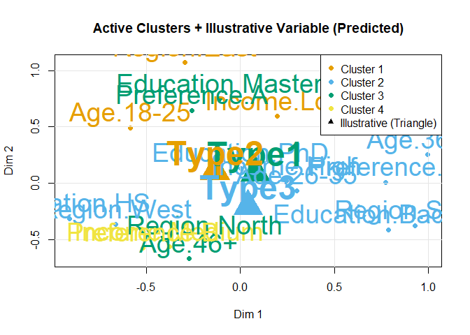

MCA with illustrative variable projection

```r
clusterer_illus$plot_mca_illustrative(
  illus = illustrative_var,
  show_labels = TRUE
)
```

## Data Export and Analysis

### MCA Coordinates

```r
# Create fresh clusterer for export examples
clusterer_export <- ModalitiesDiceClusterer$new(n_groups = 4)
clusterer_export$fit(survey_data)

# Get MCA coordinates for all modalities
mca_coords <- clusterer_export$get_mca_data(n_dims = 2)
head(mca_coords)
```

```
#>      Modality Variable  Level       Dim1        Dim2
#> 1   Age.18-25      Age .18-25 -0.5869112  0.49187394
#> 2   Age.26-35      Age .26-35  0.3009834 -0.06514835
#> 3   Age.36-45      Age .36-45  0.9954766  0.25248982
#> 4     Age.46+      Age   .46+ -0.2742821 -0.66822905
#> 5 Income.High   Income  .High  0.2459201  0.01754118
#> 6  Income.Low   Income   .Low  0.1962155  0.59257062
```

```r
# Export to CSV (example)
# write.csv(mca_coords, "mca_coordinates.csv", row.names = FALSE)
```

### Cluster Data with Metadata

```r
# Get complete clustering data
cluster_data <- clusterer_export$get_cluster_data(n_dims = 2)
head(cluster_data)
```

```
#>             Modality   Variable     Level Cluster Frequency       Dim1
#> 1         Income.Low     Income      .Low       1        51  0.1962155
#> 2          Age.18-25        Age    .18-25       1        45 -0.5869112
#> 3        Region.East     Region     .East       1        42 -0.2969590
#> 4       Preference.C Preference        .C       2        51  0.7743527
#> 5 Education.Bachelor  Education .Bachelor       2        48  0.7873496
#> 6        Income.High     Income     .High       2        44  0.2459201
#>          Dim2 VarExplained_Dim1 VarExplained_Dim2
#> 1  0.59257062          11.38838          10.33271
#> 2  0.49187394          11.38838          10.33271
#> 3  1.06858761          11.38838          10.33271
#> 4  0.01072978          11.38838          10.33271
#> 5 -0.41248769          11.38838          10.33271
#> 6  0.01754118          11.38838          10.33271
```

```r
# Analyze cluster composition by variable
table(cluster_data$Variable, cluster_data$Cluster)
```

```
#>
#>              1 2 3 4
#>   Age        1 2 1 0
#>   Education  0 3 1 0
#>   Income     1 1 0 1
#>   Preference 0 1 1 1
#>   Region     1 2 1 0
```

### Cluster Statistics

```r
# Comprehensive statistics per cluster
stats <- clusterer_export$get_cluster_stats(n_dims = 2)
print(stats)
```

```
#>   Cluster Size TotalFrequency AvgFrequency Centroid_Dim1 Centroid_Dim2
#> 1       1    3            138     46.00000    -0.2292182    0.71767739
#> 2       2    9            347     38.55556     0.2734900   -0.12396320
#> 3       3    4            157     39.25000    -0.2080891    0.05485412
#> 4       4    2            108     54.00000    -0.4488646   -0.56737050
#>   WithinVariance
#> 1    0.167767948
#> 2    0.479599516
#> 3    0.420955052
#> 4    0.004940599
#>                                                                                                                    Modalities
#> 1                                                                                          Income.Low, Age.18-25, Region.East
#> 2 Preference.C, Education.Bachelor, Income.High, Age.26-35, Region.South, Education.HS, Region.West, Education.PhD, Age.36-45
#> 3                                                                       Preference.A, Age.46+, Education.Master, Region.North
#> 4                                                                                                 Income.Medium, Preference.B
```

### Silhouette Data

```r
# Get silhouette coefficients for all modalities
sil_data <- clusterer_export$get_silhouette_data()
head(sil_data)
```

```
#>       Modality Cluster Silhouette AvgDistWithin MinAvgDistOther NearestCluster
#> 1    Age.18-25       1 0.07145966      5.308758        5.717316              2
#> 2  Region.East       1 0.06901097      5.240571        5.629037              3
#> 3   Income.Low       1 0.02111690      5.499577        5.618217              3
#> 4 Region.South       2 0.07652225      5.344418        5.787274              4
#> 5    Age.26-35       2 0.05603913      5.463416        5.787757              4
#> 6 Preference.C       2 0.04370962      5.506666        5.758362              1
```

```r
# Find poorly clustered modalities
poorly_clustered <- sil_data[sil_data$Silhouette < 0, ]
if (nrow(poorly_clustered) > 0) {
  cat("\nPoorly clustered modalities (negative silhouette):\n")
  print(poorly_clustered)
} else {
  cat("\nNo poorly clustered modalities (all silhouette > 0)\n")
}
```

```
#>
#> Poorly clustered modalities (negative silhouette):
#>         Modality Cluster  Silhouette AvgDistWithin MinAvgDistOther
#> 11 Education.PhD       2 -0.01468743      5.336531        5.258151
#> 12  Education.HS       2 -0.02891427      5.544685        5.384364
#>    NearestCluster
#> 11              1
#> 12              4
```

```r
# Average silhouette by cluster
aggregate(Silhouette ~ Cluster, data = sil_data, FUN = mean)
```

```
#>   Cluster Silhouette
#> 1       1 0.05386251
#> 2       2 0.02642954
#> 3       3 0.06136708
#> 4       4 0.04556700
```

## Advanced Analysis

### Distance and Similarity Matrices

```r
# Get dissimilarity matrix
dissim_matrix <- clusterer_export$measure_dissimilarity(as_dist = FALSE)
cat("Dissimilarity matrix dimensions:", dim(dissim_matrix), "\n")
```

```
#> Dissimilarity matrix dimensions: 18 18
```

```r
# Get similarity matrix (normalized to [0,1])
sim_matrix <- clusterer_export$measure_similarity(normalize = TRUE)
cat("Similarity range: [",
    round(min(sim_matrix), 3), ", ",
    round(max(sim_matrix), 3), "]\n", sep = "")
```

```
#> Similarity range: [0, 1]
```

```r
# Find most similar modality pairs
sim_matrix_lower <- sim_matrix
sim_matrix_lower[upper.tri(sim_matrix_lower, diag = TRUE)] <- NA
top_pairs <- which(sim_matrix_lower > 0.8, arr.ind = TRUE)
if (nrow(top_pairs) > 0) {
  cat("\nHighly similar modality pairs (similarity > 0.8):\n")
  for (i in 1:min(5, nrow(top_pairs))) {
    row_idx <- top_pairs[i, 1]
    col_idx <- top_pairs[i, 2]
    cat(sprintf("  %s <-> %s: %.3f\n",
                rownames(sim_matrix)[row_idx],
                colnames(sim_matrix)[col_idx],
                sim_matrix[row_idx, col_idx]))
  }
}
```

### Inertia Decomposition

```r
summary_res <- clusterer_export$summary()
```

```
#> ================================================================================
#>                     MODALITIES DICE CLUSTERER SUMMARY
#> ================================================================================
#>
#> --- MODEL CONFIGURATION ---
#> Dissimilarity measure: DICE
#> Linkage method: ward.D2
#> Number of clusters: 4
#> Auto-discretization: Yes (n_bins=4)
#>
#> --- DATA INFORMATION ---
#> Number of observations: 150
#> Number of variables: 5
#> Number of modalities: 18
#> Modalities: Age.18-25, Age.26-35, Age.36-45, Age.46+, Income.High, Income.Low, Income.Medium, Education.Bachelor, Education.HS, Education.Master, Education.PhD, Region.East, Region.North, Region.South, Region.West, Preference.A, Preference.B, Preference.C
#>
#> --- CLUSTER ASSIGNMENTS ---
#> Cluster sizes (n_modalities): 3, 9, 4, 2
#>
#> Detailed cluster composition:
#>
#> Cluster 1 (3 modalities, total freq: 138):
#>   - Income.Low (freq: 51, 34.0%)
#>   - Age.18-25 (freq: 45, 30.0%)
#>   - Region.East (freq: 42, 28.0%)
#>
#> Cluster 2 (9 modalities, total freq: 347):
#>   - Preference.C (freq: 51, 34.0%)
#>   - Education.Bachelor (freq: 48, 32.0%)
#>   - Income.High (freq: 44, 29.3%)
#>   - Age.26-35 (freq: 43, 28.7%)
#>   - Region.South (freq: 42, 28.0%)
#>   - Education.HS (freq: 37, 24.7%)
#>   - Region.West (freq: 30, 20.0%)
#>   - Education.PhD (freq: 28, 18.7%)
#>   - Age.36-45 (freq: 24, 16.0%)
#>
#> Cluster 3 (4 modalities, total freq: 157):
#>   - Preference.A (freq: 46, 30.7%)
#>   - Age.46+ (freq: 38, 25.3%)
```

[output cut: 29 more lines]

```
#>  7. Age.18-25 (cluster 1): 32.6471 (5.69%)
#>  8. Income.High (cluster 2): 32.4118 (5.65%)
#>  9. Age.26-35 (cluster 2): 32.1765 (5.61%)
#> 10. Region.East (cluster 1): 31.9412 (5.57%)
#>
#> --- DISTANCE MATRIX STATISTICS ---
#> Distance range: [4.5826, 7.2801]
#> Mean distance: 5.6248
#> Median distance: 5.5678
#>
#> --- HIERARCHICAL CLUSTERING DETAILS ---
#> Height range: [4.5826, 7.0548]
#> Number of merges: 17
#>
#> ================================================================================
```

```r
cat("=== Inertia Analysis ===\n\n")
```

```
#> === Inertia Analysis ===
```

```r
if (!is.null(summary_res$inertia) && is.numeric(summary_res$inertia)) {
  total_inertia <- summary_res$inertia["total"]
  between_inertia <- summary_res$inertia["between"]
  within_inertia <- summary_res$inertia["within"]

  cat(sprintf("Total inertia: %.4f\n", total_inertia))
  if (total_inertia > 0) {
    cat(sprintf("Between-cluster inertia: %.4f (%.1f%%)\n",
                between_inertia, 100 * between_inertia / total_inertia))
    cat(sprintf("Within-cluster inertia: %.4f (%.1f%%)\n",
                within_inertia, 100 * within_inertia / total_inertia))
  }
  if (!is.null(summary_res$variance_explained) && is.numeric(summary_res$variance_explained)) {
    cat(sprintf("R² (variance explained): %.4f\n", summary_res$variance_explained))
  }
}
```

```
#> Total inertia: 270.8333
#> Between-cluster inertia: 70.1806 (25.9%)
#> Within-cluster inertia: 200.6528 (74.1%)
```

## Selecting the Optimal Number of Clusters

### Manual Comparison

```r
# Test different K values
k_values <- 2:8
results <- data.frame(
  K = k_values,
  VarExplained = numeric(length(k_values)),
  AvgSilhouette = numeric(length(k_values))
)

for (i in seq_along(k_values)) {
  k <- k_values[i]
  temp_clusterer <- ModalitiesDiceClusterer$new(n_groups = k)
  temp_clusterer$fit(survey_data)

  temp_summary <- temp_clusterer$summary()
  var_exp <- temp_summary$variance_explained
  results$VarExplained[i] <- if (!is.null(var_exp) && is.numeric(var_exp)) var_exp else NA

  sil <- temp_clusterer$get_silhouette_data()
  results$AvgSilhouette[i] <- mean(sil$Silhouette, na.rm = TRUE)
}
```

```
#> ================================================================================
#>                     MODALITIES DICE CLUSTERER SUMMARY
#> ================================================================================
#>
#> --- MODEL CONFIGURATION ---
#> Dissimilarity measure: DICE
#> Linkage method: ward.D2
#> Number of clusters: 2
#> Auto-discretization: Yes (n_bins=4)
#>
#> --- DATA INFORMATION ---
#> Number of observations: 150
#> Number of variables: 5
#> Number of modalities: 18
#> Modalities: Age.18-25, Age.26-35, Age.36-45, Age.46+, Income.High, Income.Low, Income.Medium, Education.Bachelor, Education.HS, Education.Master, Education.PhD, Region.East, Region.North, Region.South, Region.West, Preference.A, Preference.B, Preference.C
#>
#> --- CLUSTER ASSIGNMENTS ---
#> Cluster sizes (n_modalities): 7, 11
#>
#> Detailed cluster composition:
#>
#> Cluster 1 (7 modalities, total freq: 295):
#>   - Income.Low (freq: 51, 34.0%)
#>   - Preference.A (freq: 46, 30.7%)
#>   - Age.18-25 (freq: 45, 30.0%)
#>   - Region.East (freq: 42, 28.0%)
#>   - Age.46+ (freq: 38, 25.3%)
#>   - Education.Master (freq: 37, 24.7%)
#>   - Region.North (freq: 36, 24.0%)
#>
#> Cluster 2 (11 modalities, total freq: 455):
#>   - Income.Medium (freq: 55, 36.7%)
#>   - Preference.B (freq: 53, 35.3%)
#>   - Preference.C (freq: 51, 34.0%)
#>   - Education.Bachelor (freq: 48, 32.0%)
#>   - Income.High (freq: 44, 29.3%)
#>   - Age.26-35 (freq: 43, 28.7%)
#>   - Region.South (freq: 42, 28.0%)
#>   - Education.HS (freq: 37, 24.7%)
#>   - Region.West (freq: 30, 20.0%)
```

[output cut: 554 more lines]

```
#>  7. Age.18-25 (cluster 1): 32.6471 (5.69%)
#>  8. Income.High (cluster 2): 32.4118 (5.65%)
#>  9. Age.26-35 (cluster 2): 32.1765 (5.61%)
#> 10. Region.East (cluster 1): 31.9412 (5.57%)
#>
#> --- DISTANCE MATRIX STATISTICS ---
#> Distance range: [4.5826, 7.2801]
#> Mean distance: 5.6248
#> Median distance: 5.5678
#>
#> --- HIERARCHICAL CLUSTERING DETAILS ---
#> Height range: [4.5826, 7.0548]
#> Number of merges: 17
#>
#> ================================================================================
```

```r
print(results)
```

```
#>   K VarExplained AvgSilhouette
#> 1 2           NA    0.03303358
#> 2 3           NA    0.03803085
#> 3 4           NA    0.04089198
#> 4 5           NA    0.04398769
#> 5 6           NA    0.04212808
#> 6 7           NA    0.03877867
#> 7 8           NA    0.04096710
```

### Visualization of K Selection

```r
# Only plot if we have valid data
if (any(!is.na(results$VarExplained)) && any(!is.na(results$AvgSilhouette))) {
  par(mfrow = c(1, 2))

  # Variance explained (remove NAs for plotting)
  valid_var <- !is.na(results$VarExplained)
  if (any(valid_var)) {
    plot(results$K[valid_var], results$VarExplained[valid_var],
         type = "b", pch = 19, col = "steelblue",
         xlab = "Number of Clusters (K)", ylab = "Variance Explained (R²)",
         main = "Variance Explained vs K")
    grid()
  }

  # Average silhouette (remove NAs for plotting)
  valid_sil <- !is.na(results$AvgSilhouette)
  if (any(valid_sil)) {
    plot(results$K[valid_sil], results$AvgSilhouette[valid_sil],
         type = "b", pch = 19, col = "darkgreen",
         xlab = "Number of Clusters (K)", ylab = "Average Silhouette",
         main = "Silhouette Score vs K")
    grid()
  }

  par(mfrow = c(1, 1))
} else {
  cat("Unable to generate plots due to missing data\n")
}
```

```
#> Unable to generate plots due to missing data
```

## Real-World Example: Customer Segmentation

```r
# Simulate customer survey data
set.seed(2024)
n_customers <- 300

customer_data <- data.frame(
  AgeGroup = factor(sample(c("18-25", "26-35", "36-50", "51+"), n_customers,
                           replace = TRUE, prob = c(0.2, 0.35, 0.3, 0.15))),
  Income = factor(sample(c("Low", "Medium", "High", "VeryHigh"), n_customers,
                        replace = TRUE, prob = c(0.25, 0.35, 0.25, 0.15))),
  Education = factor(sample(c("HS", "College", "Bachelor", "Graduate"), n_customers,
                           replace = TRUE, prob = c(0.2, 0.25, 0.35, 0.2))),
  Occupation = factor(sample(c("Student", "Employee", "Manager", "Executive", "Retired"),
                            n_customers, replace = TRUE)),
  ProductInterest = factor(sample(c("Tech", "Fashion", "Home", "Sports", "Books"),
                                 n_customers, replace = TRUE)),
  PurchaseFreq = factor(sample(c("Rare", "Occasional", "Regular", "Frequent"),
                              n_customers, replace = TRUE,
                              prob = c(0.15, 0.35, 0.35, 0.15)))
)

# Cluster analysis
customer_clusterer <- ModalitiesDiceClusterer$new(
  n_groups = 5,
  linkage = "ward.D2",
  dissimilarity = "dice"
)

customer_clusterer$fit(customer_data)
customer_clusterer$summary()
```

```
#> ================================================================================
#>                     MODALITIES DICE CLUSTERER SUMMARY
#> ================================================================================
#>
#> --- MODEL CONFIGURATION ---
#> Dissimilarity measure: DICE
#> Linkage method: ward.D2
#> Number of clusters: 5
#> Auto-discretization: Yes (n_bins=4)
#>
#> --- DATA INFORMATION ---
#> Number of observations: 300
#> Number of variables: 6
#> Number of modalities: 26
#> Modalities: AgeGroup.18-25, AgeGroup.26-35, AgeGroup.36-50, AgeGroup.51+, Income.High, Income.Low, Income.Medium, Income.VeryHigh, Education.Bachelor, Education.College, Education.Graduate, Education.HS, Occupation.Employee, Occupation.Executive, Occupation.Manager, Occupation.Retired, Occupation…
#>
#> --- CLUSTER ASSIGNMENTS ---
#> Cluster sizes (n_modalities): 12, 5, 3, 5, 1
#>
#> Detailed cluster composition:
#>
#> Cluster 1 (12 modalities, total freq: 650):
#>   - Occupation.Retired (freq: 66, 22.0%)
#>   - Occupation.Executive (freq: 65, 21.7%)
#>   - AgeGroup.18-25 (freq: 64, 21.3%)
#>   - ProductInterest.Books (freq: 62, 20.7%)
#>   - Education.Graduate (freq: 61, 20.3%)
#>   - ProductInterest.Sports (freq: 56, 18.7%)
#>   - Income.VeryHigh (freq: 53, 17.7%)
#>   - ProductInterest.Tech (freq: 50, 16.7%)
#>   - Occupation.Employee (freq: 49, 16.3%)
#>   - AgeGroup.51+ (freq: 44, 14.7%)
#>   - PurchaseFreq.Frequent (freq: 42, 14.0%)
#>   - PurchaseFreq.Rare (freq: 38, 12.7%)
#>
#> Cluster 2 (5 modalities, total freq: 364):
#>   - AgeGroup.26-35 (freq: 110, 36.7%)
#>   - Income.Low (freq: 88, 29.3%)
#>   - ProductInterest.Home (freq: 60, 20.0%)
#>   - Occupation.Manager (freq: 55, 18.3%)
```

[output cut: 40 more lines]

```
#>  7. AgeGroup.36-50 (cluster 3): 58.9600 (4.09%)
#>  8. Income.Medium (cluster 4): 58.9600 (4.09%)
#>  9. Income.High (cluster 3): 57.5600 (4.00%)
#> 10. ProductInterest.Fashion (cluster 4): 56.1600 (3.90%)
#>
#> --- DISTANCE MATRIX STATISTICS ---
#> Distance range: [6.0000, 10.4881]
#> Mean distance: 7.4087
#> Median distance: 7.4162
#>
#> --- HIERARCHICAL CLUSTERING DETAILS ---
#> Height range: [6.0000, 9.7905]
#> Number of merges: 25
#>
#> ================================================================================
```

### Interpret Customer Segments

```r
# Get cluster composition
cluster_comp <- customer_clusterer$get_cluster_table()

cat("=== Customer Segment Interpretation ===\n\n")
```

```
#> === Customer Segment Interpretation ===
```

```r
# Show cluster assignments
for (k in 1:customer_clusterer$n_groups) {
  cat(sprintf("--- Cluster %d ---\n", k))
  cluster_mods <- cluster_comp[cluster_comp$Cluster == k, ]

  # Show modalities in this cluster
  cat("Modalities:\n")
  for (i in 1:min(10, nrow(cluster_mods))) {
    cat(sprintf("  - %s (n=%d)\n",
                cluster_mods$Modality[i],
                cluster_mods$Frequency[i]))
  }
  cat("\n")
}
```

```
#> --- Cluster 1 ---
#> Modalities:
#>   - Occupation.Retired (n=66)
#>   - Occupation.Executive (n=65)
#>   - AgeGroup.18-25 (n=64)
#>   - ProductInterest.Books (n=62)
#>   - Education.Graduate (n=61)
#>   - ProductInterest.Sports (n=56)
#>   - Income.VeryHigh (n=53)
#>   - ProductInterest.Tech (n=50)
#>   - Occupation.Employee (n=49)
#>   - AgeGroup.51+ (n=44)
#>
#> --- Cluster 2 ---
#> Modalities:
#>   - AgeGroup.26-35 (n=110)
#>   - Income.Low (n=88)
#>   - ProductInterest.Home (n=60)
#>   - Occupation.Manager (n=55)
#>   - Education.HS (n=51)
#>
#> --- Cluster 3 ---
#> Modalities:
#>   - Education.College (n=85)
#>   - AgeGroup.36-50 (n=82)
#>   - Income.High (n=77)
#>
#> --- Cluster 4 ---
#> Modalities:
#>   - PurchaseFreq.Regular (n=108)
#>   - Education.Bachelor (n=103)
#>   - Income.Medium (n=82)
#>   - ProductInterest.Fashion (n=72)
#>   - Occupation.Student (n=65)
#>
#> --- Cluster 5 ---
#> Modalities:
#>   - PurchaseFreq.Occasional (n=112)
```

### Visualize Customer Segments

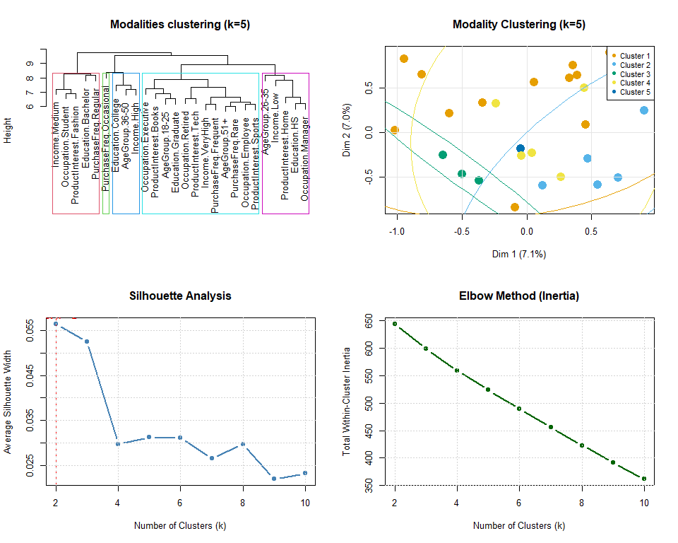

```r
par(mfrow = c(2, 2))

# Dendrogram
customer_clusterer$plot_dendrogram()

# MCA projection
customer_clusterer$plot_mca(
  color_by_cluster = TRUE,
  add_ellipses = TRUE,
  show_labels = FALSE,
  point_size = 2
)

# Silhouette
customer_clusterer$plot_silhouette(min_k = 2, max_k = 10)

# Elbow
customer_clusterer$plot_elbow(min_k = 2, max_k = 10)
```

```r
par(mfrow = c(1, 1))
```

## Best Practices

### When to Use ModalitiesDiceClusterer

1. **Categorical data analysis**: Survey responses, customer attributes, product features
2. **Mixed data exploration**: Combine numeric and categorical variables via discretization
3. **Pattern discovery**: Understand which categories naturally group together
4. **Dimension reduction**: Create synthetic variables from grouped modalities
5. **Market segmentation**: Identify customer segments based on attributes

### Parameter Selection Guidelines

| Scenario | Recommended Settings |
| --- | --- |
| **Survey data** | `dissimilarity = "dice"`, `linkage = "ward.D2"` |
| **Mixed data** | `auto_discretize = TRUE`, `n_bins = 4` |
| **Many categories** | Start with higher K, use elbow/silhouette to refine |
| **Highly structured** | `linkage = "complete"` for clear separation |
| **Exploratory** | Try both “dice” and “cramer” dissimilarity |

### Interpretation Tips

- **High R²** (>0.6): Strong cluster structure, reliable segmentation
- **Low silhouette** (<0.25): Consider fewer clusters or check data quality
- **Negative silhouette**: Modality may belong to different cluster
- **Within-cluster inertia**: Lower = more homogeneous clusters

## Comparison with Other Methods

### ModalitiesDiceClusterer vs KMeansClusterer

| Aspect | ModalitiesDiceClusterer | KMeansClusterer |
| --- | --- | --- |
| **Clusters** | Modalities (categories) | Variables |
| **Input** | Categorical/Mixed | Numeric |
| **Method** | Hierarchical + MCA | K-means optimization |
| **Deterministic** | Yes | No (random init) |
| **Use case** | Category relationships | Variable grouping |

### ModalitiesDiceClusterer vs DivisiveClusterer

| Aspect | ModalitiesDiceClusterer | DivisiveClusterer |
| --- | --- | --- |
| **Target** | Modalities | Variables |
| **Approach** | Hierarchical (agglomerative) | Divisive (top-down) |
| **Data type** | Categorical/Mixed | Numeric/Mixed |
| **Split history** | No | Yes (full tree) |
| **Flexibility** | Can re-cut tree | Must re-fit for changes |

## Advanced Parameter Reference

ModalitiesDiceClusterer Parameters

| Parameter | Type | Default | Options | Description |
| --- | --- | --- | --- | --- |
| n_groups | integer | - | ≥2 | Number of modality clusters |
| linkage | character | ward.D2 | ward.D2, complete, average, single | Hierarchical linkage method |
| dissimilarity | character | dice | dice, cramer | Dissimilarity measure |
| auto_discretize | logical | TRUE | TRUE/FALSE | Auto-discretize numeric variables |
| n_bins | integer | 4 | ≥2 | Number of quantile bins |

## Troubleshooting

### Common Issues

**Issue**: Too many modalities after discretization

```r
# Solution: Use fewer bins
clusterer <- ModalitiesDiceClusterer$new(n_groups = 3, n_bins = 3)
```

**Issue**: Poor clustering quality (low silhouette)

```r
# Solutions:
# 1. Try different dissimilarity measure
clusterer_cramer <- ModalitiesDiceClusterer$new(dissimilarity = "cramer")

# 2. Adjust number of clusters
clusterer$cut_tree(k = 4)

# 3. Try different linkage
clusterer_complete <- ModalitiesDiceClusterer$new(linkage = "complete")
```

**Issue**: Interpretation difficulty

```r
# Solution: Use visualizations and cluster composition
clusterer$plot_mca(color_by_cluster = TRUE, add_ellipses = TRUE)
cluster_comp <- clusterer$get_cluster_table()
print(cluster_comp)
```

## Conclusion

The `ModalitiesDiceClusterer` provides a powerful framework for analyzing categorical data structure:

- **Flexibility**: Handles pure categorical or mixed data
- **Rich diagnostics**: Inertia, silhouette, MCA projections
- **Interpretability**: Clear cluster assignments and visualizations
- **Integration**: Compatible with illustrative variables and data export

For best results: 1. Start with exploratory visualization (dendrogram, MCA) 2. Use silhouette and elbow plots to select K 3. Validate results with cluster statistics and composition 4. Iterate with different parameters if needed

## References

- Husson, F., Lê, S., & Pagès, J. (2010). *Exploratory Multivariate Analysis by Example Using R*. CRC Press.
- Chavent, M., Kuentz-Simonet, V., Liquet, B., & Saracco, J. (2012). ClustOfVar: An R Package for the Clustering of Variables. *Journal of Statistical Software*, 50(13), 1-16.
- Kaufman, L., & Rousseeuw, P. J. (1990). *Finding Groups in Data: An Introduction to Cluster Analysis*. Wiley.